# Unsupervised_Learning_Project_Part1

### Agglomerative Clustering

```python
model = AgglomerativeClustering(n_clusters = 2, affinity='euclidean', linkage='average')
```

```python
model.fit(dfscaled)
```

```
AgglomerativeClustering(linkage='average')
```

```python
df['labels'] = model.labels_
dfscaled['labels'] = model.labels_
df.head(25)
```

|  | mpg | cyl | disp | hp | wt | acc | yr | origin | acc_by_disp | GROUP | labels |
| --- | --- | --- | --- | --- | --- | --- | --- | --- | --- | --- | --- |
| 0 | 18.0 | 8 | 307.0 | 130.0 | 3504 | 12.0 | 70 | America | 0.039088 | 1 | 0 |
| 1 | 15.0 | 8 | 350.0 | 165.0 | 3693 | 11.5 | 70 | America | 0.032857 | 1 | 0 |
| 2 | 18.0 | 8 | 318.0 | 150.0 | 3436 | 11.0 | 70 | America | 0.034591 | 1 | 0 |
| 3 | 16.0 | 8 | 304.0 | 150.0 | 3433 | 12.0 | 70 | America | 0.039474 | 1 | 0 |
| 4 | 17.0 | 8 | 302.0 | 140.0 | 3449 | 10.5 | 70 | America | 0.034768 | 1 | 0 |
| 5 | 15.0 | 8 | 429.0 | 198.0 | 4341 | 10.0 | 70 | America | 0.023310 | 1 | 0 |
| 6 | 14.0 | 8 | 454.0 | 220.0 | 4354 | 9.0 | 70 | America | 0.019824 | 1 | 0 |
| 7 | 14.0 | 8 | 440.0 | 215.0 | 4312 | 8.5 | 70 | America | 0.019318 | 1 | 0 |
| 8 | 14.0 | 8 | 455.0 | 225.0 | 4425 | 10.0 | 70 | America | 0.021978 | 1 | 0 |
| 9 | 15.0 | 8 | 390.0 | 190.0 | 3850 | 8.5 | 70 | America | 0.021795 | 1 | 0 |
| 10 | 15.0 | 8 | 383.0 | 170.0 | 3563 | 10.0 | 70 | America | 0.026110 | 1 | 0 |
| 11 | 14.0 | 8 | 340.0 | 160.0 | 3609 | 8.0 | 70 | America | 0.023529 | 1 | 0 |
| 12 | 15.0 | 8 | 400.0 | 150.0 | 3761 | 9.5 | 70 | America | 0.023750 | 1 | 0 |
| 13 | 14.0 | 8 | 455.0 | 225.0 | 3086 | 10.0 | 70 | America | 0.021978 | 1 | 0 |
| 14 | 24.0 | 4 | 113.0 | 95.0 | 2372 | 15.0 | 70 | Asia | 0.132743 | 0 | 1 |
| 15 | 22.0 | 6 | 198.0 | 95.0 | 2833 | 15.5 | 70 | America | 0.078283 | 0 | 1 |
| 16 | 18.0 | 6 | 199.0 | 97.0 | 2774 | 15.5 | 70 | America | 0.077889 | 0 | 1 |
| 17 | 21.0 | 6 | 200.0 | 85.0 | 2587 | 16.0 | 70 | America | 0.080000 | 0 | 1 |
| 18 | 27.0 | 4 | 97.0 | 88.0 | 2130 | 14.5 | 70 | Asia | 0.149485 | 0 | 1 |
| 19 | 26.0 | 4 | 97.0 | 46.0 | 1835 | 20.5 | 70 | Europe | 0.211340 | 0 | 1 |
| 20 | 25.0 | 4 | 110.0 | 87.0 | 2672 | 17.5 | 70 | Europe | 0.159091 | 0 | 1 |
| 21 | 24.0 | 4 | 107.0 | 90.0 | 2430 | 14.5 | 70 | Europe | 0.135514 | 0 | 1 |
| 22 | 25.0 | 4 | 104.0 | 95.0 | 2375 | 17.5 | 70 | Europe | 0.168269 | 0 | 1 |
| 23 | 26.0 | 4 | 121.0 | 113.0 | 2234 | 12.5 | 70 | Europe | 0.103306 | 0 | 1 |
| 24 | 21.0 | 6 | 199.0 | 90.0 | 2648 | 15.0 | 70 | America | 0.075377 | 0 | 1 |

```python
dfscaled = dfscaled.drop('GROUP', axis = 1)
```

```python
df[df.labels == df.GROUP]
```

|  | mpg | cyl | disp | hp | wt | acc | yr | origin | acc_by_disp | GROUP | labels |
| --- | --- | --- | --- | --- | --- | --- | --- | --- | --- | --- | --- |
| 45 | 18.0 | 6 | 258.0 | 110.0 | 2962 | 13.5 | 71 | America | 0.052326 | 1 | 1 |
| 300 | 23.9 | 8 | 260.0 | 90.0 | 3420 | 22.2 | 79 | America | 0.085385 | 0 | 0 |

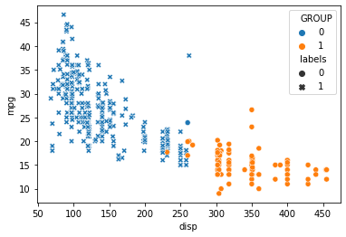

```python
sns.scatterplot(df.disp,df.mpg, hue = df.GROUP, style = df.labels);
```

```
array([[<AxesSubplot:title={'center':'acc'}, xlabel='[labels]'>,
        <AxesSubplot:title={'center':'cyl'}, xlabel='[labels]'>,
        <AxesSubplot:title={'center':'disp'}, xlabel='[labels]'>],
       [<AxesSubplot:title={'center':'hp'}, xlabel='[labels]'>,
        <AxesSubplot:title={'center':'wt'}, xlabel='[labels]'>,
        <AxesSubplot:title={'center':'yr'}, xlabel='[labels]'>]],
      dtype=object)
```

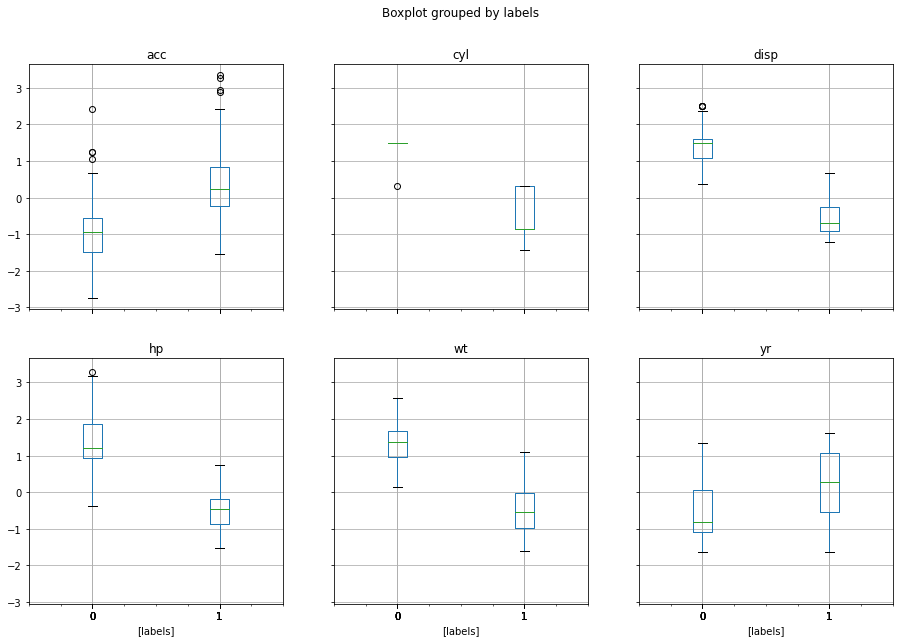

```python
dfscaled.boxplot(by='labels', layout = (2,3),figsize=(15,10))
```

##### The clusters are almost the same

```python
from scipy.cluster.hierarchy import cophenet, dendrogram, linkage
```

```python
from scipy.spatial.distance import pdist
```

```python
z = linkage(dfscaled, metric = 'euclidean', method = 'average')
c, coph_dist = cophenet(z, pdist(dfscaled))
c
```

```
0.8251576642657705
```

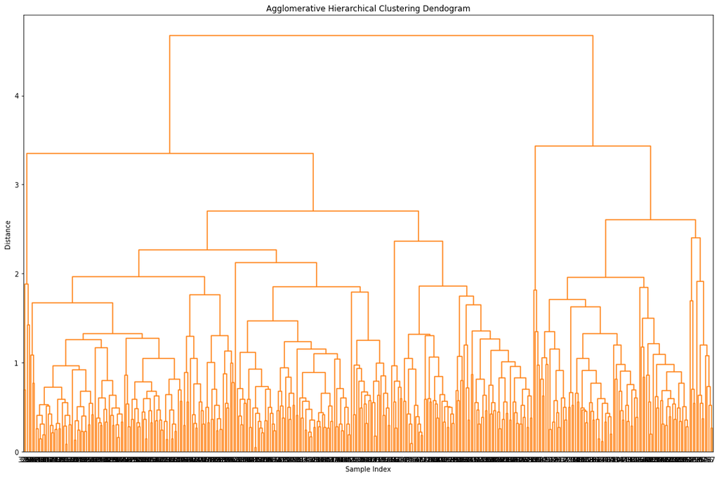

```python
plt.figure(figsize = (15,10))
plt.title('Agglomerative Hierarchical Clustering Dendogram')
plt.xlabel('Sample Index')
plt.ylabel('Distance')
dendrogram(z, leaf_rotation = 0, color_threshold = 40, leaf_font_size=10)
plt.tight_layout()
```

##### The number of clusters suggested by the dendrogram is 2, just like the K-means clustering exercise.

### Insights:

1. K means clustersing is a faster algorithm compared to the hierarchical clustering
1. The number of clusters can be found out with the elbow plot or silhouette method in K means, for Agglomerative, one has to look at the dendrogram to determine the number of clusters and sometimes it may be difficult to pick. (although sometimes it gets difficult to pick a K for K means as well)
1. The challenge with K means can be the initiation. Based on the first few points chosen the clusters may be slightly different. Therefore reproducibility can be a challenge. Results are reproducable in hierarchical clustering

## Questions based on outcomes of using ML based methods.

##### There are 2 Clusters present in the data.

These are mostly due to number of cylinders. This may also allude to the 2 groups of cars:

1. SUVs
2. Hatchbacks or small size cars

##### Linear Regression Models

```python
df
```

|  | mpg | cyl | disp | hp | wt | acc | yr | origin | acc_by_disp | GROUP | labels |
| --- | --- | --- | --- | --- | --- | --- | --- | --- | --- | --- | --- |
| 0 | 18.0 | 8 | 307.0 | 130.0 | 3504 | 12.0 | 70 | America | 0.039088 | 1 | 0 |
| 1 | 15.0 | 8 | 350.0 | 165.0 | 3693 | 11.5 | 70 | America | 0.032857 | 1 | 0 |
| 2 | 18.0 | 8 | 318.0 | 150.0 | 3436 | 11.0 | 70 | America | 0.034591 | 1 | 0 |
| 3 | 16.0 | 8 | 304.0 | 150.0 | 3433 | 12.0 | 70 | America | 0.039474 | 1 | 0 |
| 4 | 17.0 | 8 | 302.0 | 140.0 | 3449 | 10.5 | 70 | America | 0.034768 | 1 | 0 |
| ... | ... | ... | ... | ... | ... | ... | ... | ... | ... | ... | ... |
| 393 | 27.0 | 4 | 140.0 | 86.0 | 2790 | 15.6 | 82 | America | 0.111429 | 0 | 1 |
| 394 | 44.0 | 4 | 97.0 | 52.0 | 2130 | 24.6 | 82 | Europe | 0.253608 | 0 | 1 |
| 395 | 32.0 | 4 | 135.0 | 84.0 | 2295 | 11.6 | 82 | America | 0.085926 | 0 | 1 |
| 396 | 28.0 | 4 | 120.0 | 79.0 | 2625 | 18.6 | 82 | America | 0.155000 | 0 | 1 |
| 397 | 31.0 | 4 | 119.0 | 82.0 | 2720 | 19.4 | 82 | America | 0.163025 | 0 | 1 |

398 rows × 11 columns

```python
df.info()
```

```
<class 'pandas.core.frame.DataFrame'>
Int64Index: 398 entries, 0 to 397
Data columns (total 11 columns):
 #   Column       Non-Null Count  Dtype
---  ------       --------------  -----
 0   mpg          398 non-null    float64
 1   cyl          398 non-null    int64
 2   disp         398 non-null    float64
 3   hp           398 non-null    float64
 4   wt           398 non-null    int64
 5   acc          398 non-null    float64
 6   yr           398 non-null    int64
 7   origin       398 non-null    object
 8   acc_by_disp  398 non-null    float64
 9   GROUP        398 non-null    int32
 10  labels       398 non-null    int64
dtypes: float64(5), int32(1), int64(4), object(1)
memory usage: 51.9+ KB
```

```python
df = pd.get_dummies(df, columns = ['origin'])
```

```python
## Dropping one of the dummy variables as origin_America and origin_Asia capture the relevant information

df = df.drop(['origin_Europe'], axis = 1)
```

```python
df = df.drop(['labels'], axis = 1)
```

```python
df = df.drop(['acc_by_disp'], axis = 1)
```

##### Dividing the data into independent and target variable to create a Lin Reg Model

```python
X = df.iloc[:,1:]
y = df.iloc[:,0]
X = X.drop(['GROUP'], axis = 1)
```

```python
lin_model = LinearRegression()
lin_model.fit(X,y)
```

```
LinearRegression()
```

```python
AdjR2 = 1 - (1- r2_score(lin_model.predict(X),y))*((X.shape[0]-1)/(X.shape[0]-X.shape[1]-1))
```

```python
## Rsquared and AdjustedRsquared

round(r2_score(y,lin_model.predict(X)),2),round(AdjR2,2)
```

```
(0.82, 0.78)
```

##### We see that the Adjusted Rsquared for a linear model fit on the entire dataset is 0.78.

##### Our Hypothesis is that after the grouping of the data into the clusters the model fit and predictability will increase which translates into --- the average Adjusted Rsquared for the models will improve

```python
X0 = df[df.GROUP==0].iloc[:,1:]
y0 = df[df.GROUP==0].iloc[:,0]
X0 = X0.drop(['GROUP'], axis = 1)
```

```python
X1 = df[df.GROUP==1].iloc[:,1:]
y1 = df[df.GROUP==1].iloc[:,0]
X1 = X1.drop(['GROUP'], axis = 1)
```

```python
lin_model0 = LinearRegression()
lin_model0.fit(X0,y0)
lin_model1 = LinearRegression()
lin_model1.fit(X1,y1)
```

```
LinearRegression()
```

```python
Rsquared0 = round(r2_score(y0,lin_model0.predict(X0)),2)
AdjRsquared0 = round(1 - (1- Rsquared0)*(X0.shape[0]-1)/(X0.shape[0]-X0.shape[1]-1),2)
```

```python
Rsquared0, AdjRsquared0
```

```
(0.78, 0.77)
```

```python
Rsquared1 = round(r2_score(y1,lin_model1.predict(X1)),2)
AdjRsquared1 = round(1 - (1- Rsquared1)*(X1.shape[0]-1)/(X1.shape[0]-X1.shape[1]-1),2)
```

```python
Rsquared1, AdjRsquared1
```

```
(0.62, 0.59)
```

```python
print('The length of the X1 dataset is',X1.shape[0])
```

```
The length of the X1 dataset is 104
```

We see that the average Adj Rsquared for the two new models is less than the Adj Rsquared of the original single model

However, that is because the X1 dataset has only 104 observations

##### Original Model

```python
for idx, col_name in enumerate(X.columns):
    print(f'The coefficient for {col_name} is {round(lin_model.coef_[idx],3)}')
```

```
The coefficient for cyl is -0.423
The coefficient for disp is 0.024
The coefficient for hp is -0.014
The coefficient for wt is -0.007
The coefficient for acc is 0.095
The coefficient for yr is 0.783
The coefficient for origin_America is -2.789
The coefficient for origin_Asia is 0.052
```

##### Model for Cluster 0

```python
for idx, col_name in enumerate(X0.columns):
    print(f'The coefficient for {col_name} is {round(lin_model0.coef_[idx],3)}')
```

```
The coefficient for cyl is 0.503
The coefficient for disp is -0.001
The coefficient for hp is -0.08
The coefficient for wt is -0.007
The coefficient for acc is 0.016
The coefficient for yr is 0.873
The coefficient for origin_America is -1.805
The coefficient for origin_Asia is -0.34
```

##### Model for Cluster 1

```python
for idx, col_name in enumerate(X1.columns):
    print(f'The coefficient for {col_name} is {round(lin_model1.coef_[idx],3)}')
```

```
The coefficient for cyl is -0.655
The coefficient for disp is 0.02
The coefficient for hp is -0.031
The coefficient for wt is -0.003
The coefficient for acc is 0.087
The coefficient for yr is 0.396
The coefficient for origin_America is 0.0
The coefficient for origin_Asia is 0.0
```

##### In an experiment I had also tried creating a variable disp/cyl and removed cyl to see if clusters change.

##### There was no change in the clusters or the modelling results

### Question:

How using different models for different clusters will be helpful in this case and how it will be different than using one single model without clustering? Mention how it impacts performance and prediction.

### Answer:

In different clusters different models can be used to fit the data. We can also look at different algorithms to see what fits the data the best.

In this scenario, we see that linear regression does not perform very well on the data. However, other algorithms can be applied to the different clusters to improve results

If each cluster has enough data to train the model, then performance and prediction would in most cases go up. However, an alternative to this can be using a non linear model

### Suggestions or Improvements

1. Quality of data can be improved. For example some data points for the column hp were missing. We add bias when we perform data imputation
2. Quantity of data also needs to improve. 398 data points are not enough to fit a model especially when we are looking at clustering and fitting a different model for each cluster
3. There are no concerns around variety, velocity or veracity of the data